# Pemodelan dengan Random Forest dan Gradient Boosting Studi Kasus Prediksi Body Mass Index

Nazuwa Aulia

2023-11-26

# Packages

```r
library(stringr)
library(dplyr)
library(caret)
library(ranger)
library(gbm)
library(lime)
library(MLmetrics)
```

```r
library(cowplot)
library(skimr)
library(randomForest)
library(UBL)
library(vcdExtra)
library(ggplot2)
```

# Data

```r
dt.obes <- read.csv("C:/Users/Nazuwa Aulia/OneDrive/Documents/College/Semester 5/Pengantar Sains Data/Project UAS/obesitas tanpa 2 var.csv", stringsAsFactors = TRUE)
head(dt.obes)
```

```
##   Gender Age family_history_with_overweight FAVC FCVC NCP      CAEC SMOKE CH2O
## 1 Female  21                            yes   no    2   3 Sometimes    no    2
## 2 Female  21                            yes   no    3   3 Sometimes   yes    3
## 3   Male  23                            yes   no    2   3 Sometimes    no    2
## 4   Male  27                             no   no    3   3 Sometimes    no    2
## 5   Male  22                             no   no    2   1 Sometimes    no    2
## 6   Male  29                             no  yes    2   3 Sometimes    no    2
##   SCC FAF TUE       CALC                MTRANS    obesity
## 1  no   0   1         no Public_Transportation     Normal
## 2 yes   3   0  Sometimes Public_Transportation     Normal
## 3  no   2   1 Frequently Public_Transportation     Normal
## 4  no   2   0 Frequently               Walking Overweight
## 5  no   0   0  Sometimes Public_Transportation Overweight
## 6  no   0   0  Sometimes            Automobile     Normal
```

# Eksplorasi Data

```r
skimr::skim(dt.obes)
```

Data summary

| Name | dt.obes |
| --- | --- |
| Number of rows | 2111 |
| Number of columns | 15 |
| _______________________ |  |
| Column type frequency: |  |
| factor | 9 |
| numeric | 6 |
| ________________________ |  |
| Group variables | None |

**Variable type: factor**

| skim_variable | n_missing | complete_rate | ordered | n_unique | top_counts |
| --- | --- | --- | --- | --- | --- |
| Gender | 0 | 1 | FALSE | 2 | Mal: 1068, Fem: 1043 |
| family_history_with_overweight | 0 | 1 | FALSE | 2 | yes: 1726, no: 385 |
| FAVC | 0 | 1 | FALSE | 2 | yes: 1866, no: 245 |
| CAEC | 0 | 1 | FALSE | 4 | Som: 1765, Fre: 242, Alw: 53, no: 51 |
| SMOKE | 0 | 1 | FALSE | 2 | no: 2067, yes: 44 |
| SCC | 0 | 1 | FALSE | 2 | no: 2015, yes: 96 |
| CALC | 0 | 1 | FALSE | 4 | Som: 1401, no: 639, Fre: 70, Alw: 1 |
| MTRANS | 0 | 1 | FALSE | 5 | Pub: 1580, Aut: 457, Wal: 56, Mot: 11 |
| obesity | 0 | 1 | FALSE | 4 | Obe: 972, Ove: 580, Nor: 287, Ins: 272 |

**Variable type: numeric**

| skim_variable | n_missing | complete_rate | mean | sd | p0 | p25 | p50 | p75 | p100 | hist |
| --- | --- | --- | --- | --- | --- | --- | --- | --- | --- | --- |
| Age | 0 | 1 | 24.31 | 6.35 | 14 | 19.95 | 22.78 | 26.00 | 61 | ▇▅▂▁▁ |
| FCVC | 0 | 1 | 2.42 | 0.53 | 1 | 2.00 | 2.39 | 3.00 | 3 | ▁▁▇▂▇ |
| NCP | 0 | 1 | 2.69 | 0.78 | 1 | 2.66 | 3.00 | 3.00 | 4 | ▂▁▁▇▁ |
| CH2O | 0 | 1 | 2.01 | 0.61 | 1 | 1.58 | 2.00 | 2.48 | 3 | ▅▂▇▂▅ |
| FAF | 0 | 1 | 1.01 | 0.85 | 0 | 0.12 | 1.00 | 1.67 | 3 | ▇▆▃▃▂ |
| TUE | 0 | 1 | 0.66 | 0.61 | 0 | 0.00 | 0.63 | 1.00 | 2 | ▇▃▅▁▂ |

```r
summary(dt.obes)
```

```
##     Gender          Age        family_history_with_overweight  FAVC
##  Female:1043   Min.   :14.00   no : 385                       no : 245
##  Male  :1068   1st Qu.:19.95   yes:1726                       yes:1866
##                Median :22.78
##                Mean   :24.31
##                3rd Qu.:26.00
##                Max.   :61.00
##       FCVC            NCP                CAEC      SMOKE           CH2O
##  Min.   :1.000   Min.   :1.000   Always    :  53   no :2067   Min.   :1.000
##  1st Qu.:2.000   1st Qu.:2.659   Frequently: 242   yes:  44   1st Qu.:1.585
##  Median :2.386   Median :3.000   no        :  51              Median :2.000
##  Mean   :2.419   Mean   :2.686   Sometimes :1765              Mean   :2.008
##  3rd Qu.:3.000   3rd Qu.:3.000                                3rd Qu.:2.477
##  Max.   :3.000   Max.   :4.000                                Max.   :3.000
##   SCC            FAF              TUE                 CALC
##  no :2015   Min.   :0.0000   Min.   :0.0000   Always    :   1
##  yes:  96   1st Qu.:0.1245   1st Qu.:0.0000   Frequently:  70
##             Median :1.0000   Median :0.6253   no        : 639
##             Mean   :1.0103   Mean   :0.6579   Sometimes :1401
##             3rd Qu.:1.6667   3rd Qu.:1.0000
##             Max.   :3.0000   Max.   :2.0000
##                    MTRANS             obesity
##  Automobile           : 457   Insufficient:272
##  Bike                 :   7   Normal      :287
##  Motorbike            :  11   Obesity     :972
##  Public_Transportation:1580   Overweight  :580
##  Walking              :  56
##
```

# Visualisasi Data

## Sebaran Peubah Respon

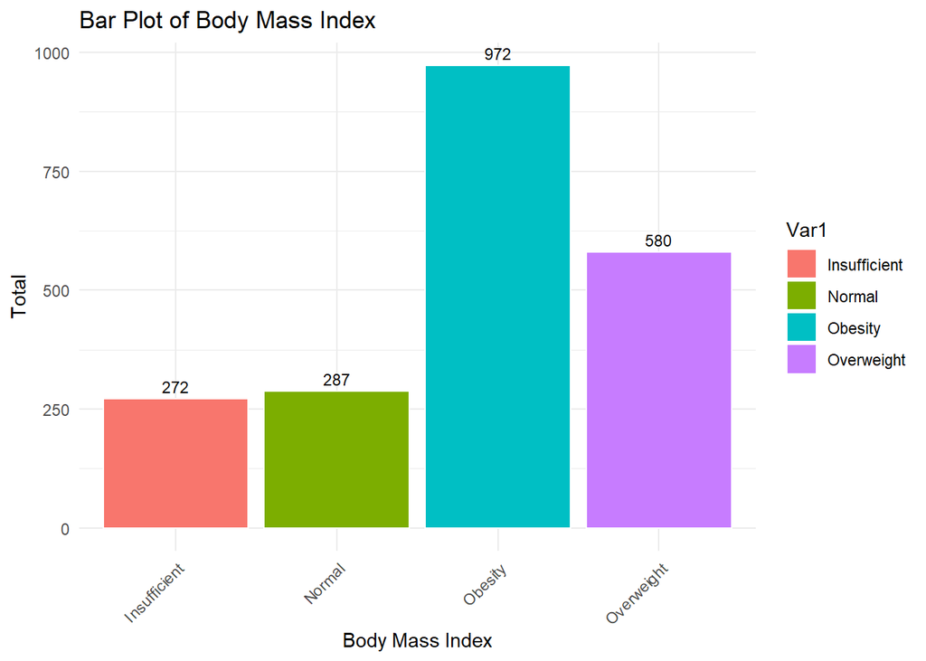

```r
table_obes <- table(dt.obes$obesity)
df_obes <- as.data.frame(table_obes)

bar.ploty <- ggplot(df_obes, aes(x = Var1, y = Freq, fill = Var1)) +
  geom_bar(stat = "identity", color = "white") +
  geom_text(aes(label = Freq), vjust = -0.5, size = 3) +
  theme_minimal() +
  labs(title = "Bar Plot of Body Mass Index", x = "Body Mass Index", y = "Total") +
  theme(axis.text.x = element_text(angle = 45, hjust = 1))

bar.ploty
```

Berdasarkan bar plot tersebut data cenderung imbalanced oleh karena itu pada analasis ini akan dilakukan perbandingan metode random forest dan gradient boosting pada masing-masing penanganan data yaitu undersampling, oversampling dan smote.

## Sebaran Peubah Kategorik

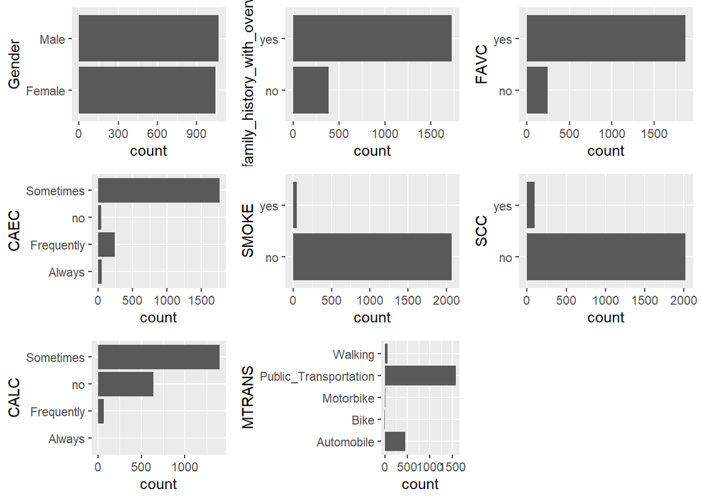

```r
count_categoric_features <- function(x){
  ggplot(dt.obes, aes_string(x = x)) +
    geom_bar() +
    coord_flip()
}

plot_grid(
  count_categoric_features("Gender"),
  count_categoric_features("family_history_with_overweight"),
  count_categoric_features("FAVC"),
  count_categoric_features("CAEC"),
  count_categoric_features("SMOKE"),
  count_categoric_features("SCC"),
  count_categoric_features("CALC"),
  count_categoric_features("MTRANS"))
```

# Splitting Data

```r
set.seed(123)
train_idx <- createDataPartition(dt.obes$obesity, p = 0.8, list=FALSE)
trainData <- dt.obes[train_idx,]
testData <- dt.obes[-train_idx,]
```

# Modeling

K-fold cross validation adalah salah satu teknik validasi untuk mencari tuning parameter terbaik sekaligus mengevaluasi kinerja model. Pada studi kasus ini digunakan 5-fold cross validation. Data dipartisi secara acak ke dalam lima subset data. Secara bergantian masing-masing subset akan dijadikan sebagai data testing, sementara empat subset data lainnya sebagai data training.

Pemodelan dilakukan dengan mencari Tuning Parameter dengan tuneLength. Opsi tuneLength pada fungsi caret::train akan memilih sejumlah tuning parameter atau kombinasi tuning parameter yang dianggap paling tepat sesuai dengan metode yang dipilih dan data training yang diberikan.

```r
set.seed(123)
fitControl <- trainControl(
  method = "cv",
  number = 5,
  returnResamp = "all")
```

## Tanpa Penanganan

### Modeling 1: Random Forest

#### Cross Validation

```r
set.seed(123)
rf <- train(obesity ~ .,
            data = trainData,
            method = 'ranger',
            tuneLength = 10,
            importance = "impurity",
            trControl = fitControl,
            verbose = FALSE)
rf
```

```
## Random Forest
##
## 1690 samples
##   14 predictor
##    4 classes: 'Insufficient', 'Normal', 'Obesity', 'Overweight'
##
## No pre-processing
## Resampling: Cross-Validated (5 fold)
## Summary of sample sizes: 1351, 1352, 1352, 1354, 1351
## Resampling results across tuning parameters:
##
##   mtry  splitrule   Accuracy   Kappa
##    2    gini        0.7739902  0.6516552
##    2    extratrees  0.6970962  0.5183918
##    4    gini        0.8455553  0.7696729
##    4    extratrees  0.7893434  0.6804145
##    6    gini        0.8615299  0.7947034
##    6    extratrees  0.8408268  0.7632310
##    8    gini        0.8573966  0.7886730
##    8    extratrees  0.8485191  0.7749999
##   10    gini        0.8579936  0.7897261
##   10    extratrees  0.8455570  0.7705892
##   12    gini        0.8574195  0.7888974
##   12    extratrees  0.8479379  0.7739635
##   14    gini        0.8538515  0.7837206
##   14    extratrees  0.8443963  0.7684717
##   16    gini        0.8455622  0.7713441
##   16    extratrees  0.8485226  0.7747758
##   18    gini        0.8473462  0.7740215
##   18    extratrees  0.8479414  0.7737908
##   21    gini        0.8390393  0.7618705
##   21    extratrees  0.8479344  0.7738730
##
## Tuning parameter 'min.node.size' was held constant at a value of 1
## Accuracy was used to select the optimal model using the largest value.
## The final values used for the model were mtry = 6, splitrule = gini
##  and min.node.size = 1.
```

Hasil Validasi silang didapatkan plot sebagai berikut

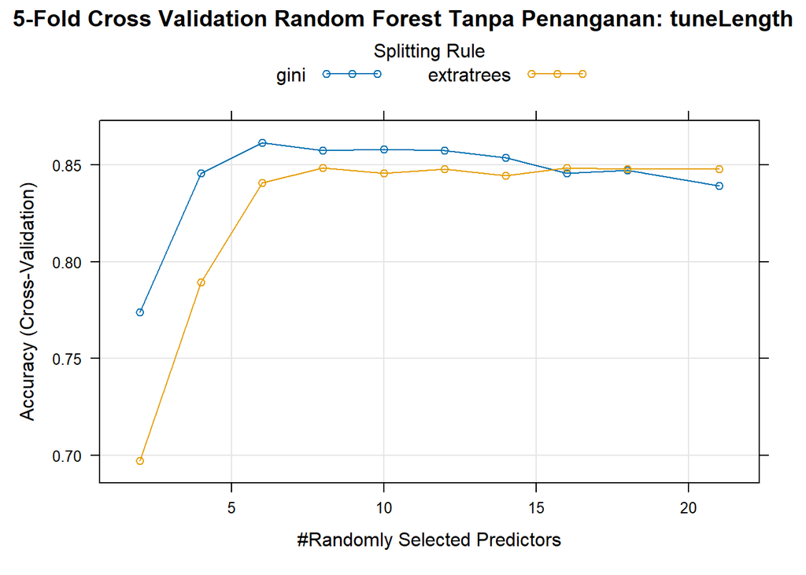

```r
plot(rf, main = "5-Fold Cross Validation Random Forest Tanpa Penanganan: tuneLength")
```

```r
rf_best <- rf$bestTune
rf_best
```

```
##   mtry splitrule min.node.size
## 5    6      gini             1
```

Berdasarkan output di atas, tuning parameter terbaik adalah mtry = 6, splitrule = gini dan min.node.size = 1, yang memberikan nilai akurasi sebesar 0.8615299

#### Re-Fit Model Menggunakan Tuning Parameter Terbaik

```r
set.seed(123)
rf <- train(obesity ~ .,
            data = trainData,
            method = 'ranger',
            tuneGrid  = rf_best,
            importance = "impurity",
            verbose = FALSE)
rf
```

```
## Random Forest
##
## 1690 samples
##   14 predictor
##    4 classes: 'Insufficient', 'Normal', 'Obesity', 'Overweight'
##
## No pre-processing
## Resampling: Bootstrapped (25 reps)
## Summary of sample sizes: 1690, 1690, 1690, 1690, 1690, 1690, ...
## Resampling results:
##
##   Accuracy   Kappa
##   0.8360162  0.7575456
##
## Tuning parameter 'mtry' was held constant at a value of 6
## Tuning
##  parameter 'splitrule' was held constant at a value of gini
## Tuning
##  parameter 'min.node.size' was held constant at a value of 1
```

```r
rf_result <- rf$results
rf_result
```

```
##   mtry splitrule min.node.size  Accuracy     Kappa AccuracySD    KappaSD
## 1    6      gini             1 0.8360162 0.7575456 0.01317224 0.01895628
```

Diperoleh model dengan Accuracy = 0.8360162 dan Kappa = 0.7575456

#### Model (mtry=6)

```r
set.seed(123)
rf_mod<-randomForest(obesity~., data = trainData, mtry=6)
rf_mod
```

```
##
## Call:
##  randomForest(formula = obesity ~ ., data = trainData, mtry = 6)
##                Type of random forest: classification
##                      Number of trees: 500
## No. of variables tried at each split: 6
##
##         OOB estimate of  error rate: 13.55%
## Confusion matrix:
##              Insufficient Normal Obesity Overweight class.error
## Insufficient          199     14       1          4  0.08715596
## Normal                  9    166      16         39  0.27826087
## Obesity                 1     17     733         27  0.05784062
## Overweight              2     45      54        363  0.21767241
```

#### Evaluasi Terhadap data Test

Untuk menguji kinerja model dalam memprediksi data baru, dilakukan evaluasi terhadap data testing

```r
eval_test_data <- function(model) {
  pred <- predict(model, newdata = testData)
  confusion_matrix <- confusionMatrix(pred, testData$obesity)
  Accuracy <- confusion_matrix$overall["Accuracy"]
  Kappa <- confusion_matrix$overall["Kappa"]
  return(c(Accuracy, Kappa))
}

rf_eval <- eval_test_data(rf)
rf_eval
```

```
##  Accuracy     Kappa
## 0.8337292 0.7534902
```

Diperoleh model dengan Accuracy = 0.8337292

#### Variable Importance

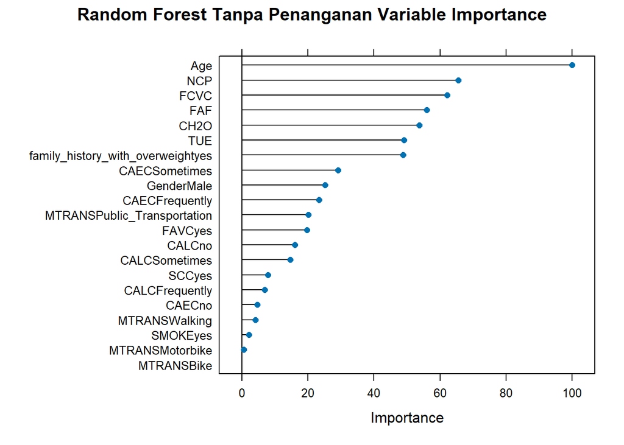

```r
plot(varImp(rf),
     main = "Random Forest Tanpa Penanganan Variable Importance" )
```

Berdasarkan output di atas, tiga peubah terpenting adalah Age,NCP, dan FCVC.

### Modeling 2: Gradient Boosting

Seperti Random Forest, pemilihan tuning parameter pada Gradient Boosting juga menggunakan 5-fold Cross-Validation.

#### Cross Validation

```r
set.seed(123)
boost <- train(obesity ~.,
               data=trainData,
               method="gbm",
               tuneLength = 10,
               trControl=fitControl,
               verbose = FALSE)
boost
```

```
## Stochastic Gradient Boosting
##
## 1690 samples
##   14 predictor
##    4 classes: 'Insufficient', 'Normal', 'Obesity', 'Overweight'
##
## No pre-processing
## Resampling: Cross-Validated (5 fold)
## Summary of sample sizes: 1351, 1352, 1352, 1354, 1351
## Resampling results across tuning parameters:
##
##   interaction.depth  n.trees  Accuracy   Kappa
##    1                  50      0.6609151  0.4762196
##    1                 100      0.6946801  0.5359471
##    1                 150      0.7207247  0.5781699
```

[output cut: 104 more lines]

Hasil validasi silang ditampilkan pada plot berikut:

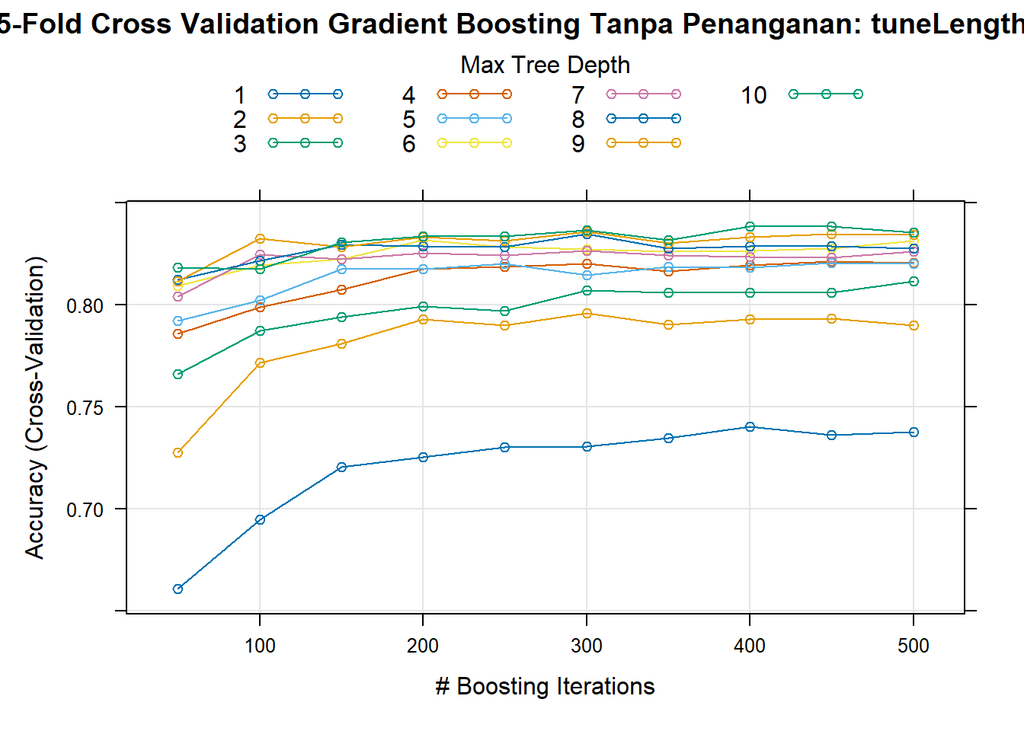

```r
plot(boost, main = "5-Fold Cross Validation Gradient Boosting Tanpa Penanganan: tuneLength")
```

```r
boost_best <- boost$bestTune
boost_best
```

```
##    n.trees interaction.depth shrinkage n.minobsinnode
## 99     450                10       0.1             10
```

Berdasarkan output di atas, tuning parameter terbaik adalah n.trees = 450, interaction.depth = 10, shrinkage = 0.1 dan n.minobsinnode = 10, yang memberikan Accuracy = 0.8384669 dan Kappa = 0.7605633

#### Re-Fit Model Menggunakan Tuning Parameter Terbaik

```r
set.seed(123)
boost <- train(obesity ~.,
               data=trainData,
               method="gbm",
               tuneGrid  = boost_best,
               verbose = FALSE)
boost
```

```
## Stochastic Gradient Boosting
##
## 1690 samples
##   14 predictor
##    4 classes: 'Insufficient', 'Normal', 'Obesity', 'Overweight'
##
## No pre-processing
## Resampling: Bootstrapped (25 reps)
## Summary of sample sizes: 1690, 1690, 1690, 1690, 1690, 1690, ...
## Resampling results:
##
##   Accuracy   Kappa
##   0.8170163  0.7289344
##
## Tuning parameter 'n.trees' was held constant at a value of 450
## Tuning
##
## Tuning parameter 'shrinkage' was held constant at a value of 0.1
##
## Tuning parameter 'n.minobsinnode' was held constant at a value of 10
```

```r
boost_result <- boost$results
boost_result
```

```
##   n.trees interaction.depth shrinkage n.minobsinnode  Accuracy     Kappa
## 1     450                10       0.1             10 0.8170163 0.7289344
##   AccuracySD    KappaSD
## 1 0.01524765 0.02249563
```

Diperoleh Accuracy = 0.8170163 dan Kappa = 0.7289344

#### Evaluasi Terhadap Data Test

```r
boost_eval <- eval_test_data(boost)
boost_eval
```

```
##  Accuracy     Kappa
## 0.8408551 0.7645119
```

Diperoleh Accuracy sebesar 0.8408551

#### Variable Importance

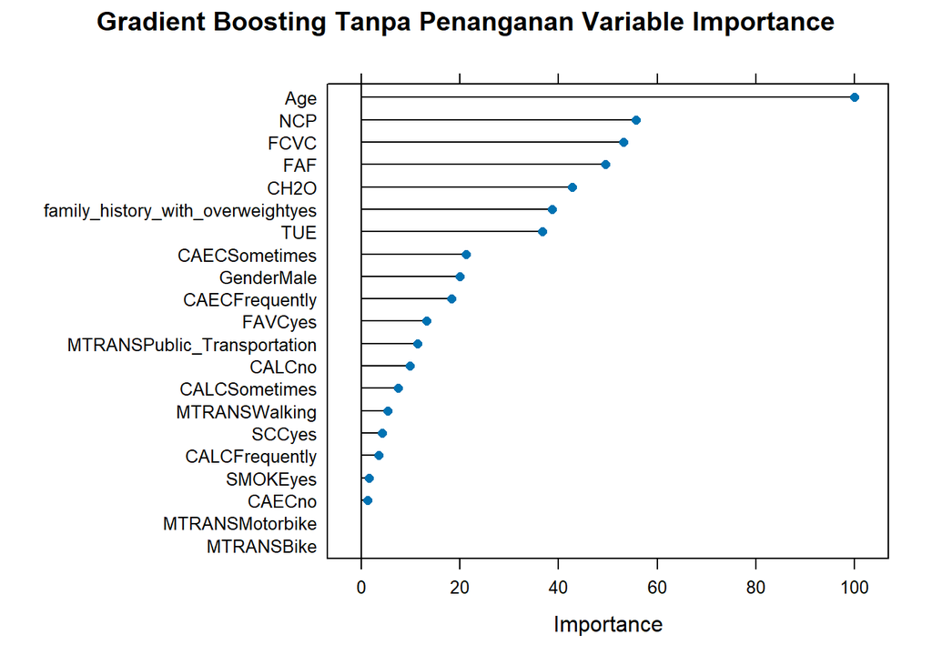

```r
plot(varImp(boost),
     main = "Gradient Boosting Tanpa Penanganan Variable Importance" )
```

Berdasarkan output di atas, tiga peubah terpenting adalah Age,NCP dan FCVC.

## Oversampling

```r
table(dt.obes$obesity)
```

```
##
## Insufficient       Normal      Obesity   Overweight
##          272          287          972          580
```

```r
# Upsample for multinomial classification
set.seed(123)
over_data <- upSample(x = trainData[, 1:14], y = trainData$obesity, yname = "obesity")
table(over_data$obesity)
```

```
##
## Insufficient       Normal      Obesity   Overweight
##          778          778          778          778
```

### Modeling 1: Random Forest

#### Cross Validation

```r
set.seed(123)
rf_over <- train(obesity ~ .,
            data = over_data,
            method = 'ranger',
            tuneLength = 10,
            importance = "impurity",
            trControl = fitControl,
            verbose = FALSE)
rf_over
```

```
## Random Forest
##
## 3112 samples
##   14 predictor
##    4 classes: 'Insufficient', 'Normal', 'Obesity', 'Overweight'
##
## No pre-processing
## Resampling: Cross-Validated (5 fold)
## Summary of sample sizes: 2490, 2491, 2488, 2490, 2489
## Resampling results across tuning parameters:
##
##   mtry  splitrule   Accuracy   Kappa
##    2    gini        0.8946027  0.8594702
##    2    extratrees  0.7882382  0.7176449
##    4    gini        0.9530835  0.9374454
##    4    extratrees  0.9244903  0.8993207
##    6    gini        0.9546876  0.9395841
##    6    extratrees  0.9495475  0.9327306
##    8    gini        0.9534071  0.9378767
##    8    extratrees  0.9559743  0.9412995
##   10    gini        0.9524419  0.9365896
##   10    extratrees  0.9537291  0.9383059
##   12    gini        0.9527635  0.9370185
##   12    extratrees  0.9546896  0.9395864
##   14    gini        0.9501942  0.9335928
##   14    extratrees  0.9527661  0.9370216
##   16    gini        0.9485906  0.9314548
##   16    extratrees  0.9527645  0.9370197
##   18    gini        0.9495506  0.9327346
##   18    extratrees  0.9508409  0.9344549
##   21    gini        0.9485865  0.9314490
##   21    extratrees  0.9517983  0.9357313
##
## Tuning parameter 'min.node.size' was held constant at a value of 1
## Accuracy was used to select the optimal model using the largest value.
## The final values used for the model were mtry = 8, splitrule = extratrees
##  and min.node.size = 1.
```

Hasil Validasi silang didapatkan plot sebagai berikut

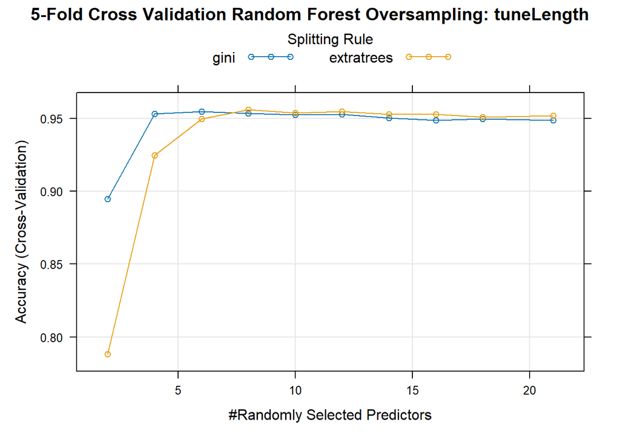

```r
plot(rf_over, main = "5-Fold Cross Validation Random Forest Oversampling: tuneLength")
```

```r
rf_over_best <- rf_over$bestTune
rf_over_best
```

```
##   mtry  splitrule min.node.size
## 8    8 extratrees             1
```

Berdasarkan output di atas, tuning parameter terbaik adalah mtry = 8, splitrule = extratrees dan min.node.size = 1, yang memberikan nilai akurasi sebesar 0.9559743

#### Re-Fit Model Menggunakan Tuning Parameter Terbaik

```r
set.seed(123)
rf_over <- train(obesity ~ .,
            data = over_data,
            method = 'ranger',
            tuneGrid  = rf_over_best,
            importance = "impurity",
            verbose = FALSE)
rf_over
```

```
## Random Forest
##
## 3112 samples
##   14 predictor
##    4 classes: 'Insufficient', 'Normal', 'Obesity', 'Overweight'
##
## No pre-processing
## Resampling: Bootstrapped (25 reps)
## Summary of sample sizes: 3112, 3112, 3112, 3112, 3112, 3112, ...
## Resampling results:
##
##   Accuracy   Kappa
##   0.9371228  0.9161226
##
## Tuning parameter 'mtry' was held constant at a value of 8
## Tuning
##  parameter 'splitrule' was held constant at a value of extratrees
##
## Tuning parameter 'min.node.size' was held constant at a value of 1
```

```r
rf_over_result <- rf_over$results
rf_over_result
```

```
##   mtry  splitrule min.node.size  Accuracy     Kappa  AccuracySD    KappaSD
## 1    8 extratrees             1 0.9371228 0.9161226 0.007609234 0.01014393
```

Diperoleh model dengan Accuracy = 0.9371228 dan Kappa = 0.9161226

#### Model (mtry=8)

```r
set.seed(123)
rf_mod2<-randomForest(obesity~., data = over_data, mtry=8)
rf_mod2
```

```
##
## Call:
##  randomForest(formula = obesity ~ ., data = over_data, mtry = 8)
##                Type of random forest: classification
##                      Number of trees: 500
## No. of variables tried at each split: 8
##
##         OOB estimate of  error rate: 3.66%
## Confusion matrix:
##              Insufficient Normal Obesity Overweight class.error
## Insufficient          775      1       0          2 0.003856041
## Normal                  0    774       2          2 0.005141388
## Obesity                 1     22     725         30 0.068123393
## Overweight              2     29      23        724 0.069408740
```

#### Evaluasi Terhadap data Test

Untuk menguji kinerja model dalam memprediksi data baru, dilakukan evaluasi terhadap data testing

```r
rf_over_eval <- eval_test_data(rf_over)
rf_over_eval
```

```
##  Accuracy     Kappa
## 0.8432304 0.7690793
```

Diperoleh model dengan Accuracy = 0.8432304

#### Variable Importance

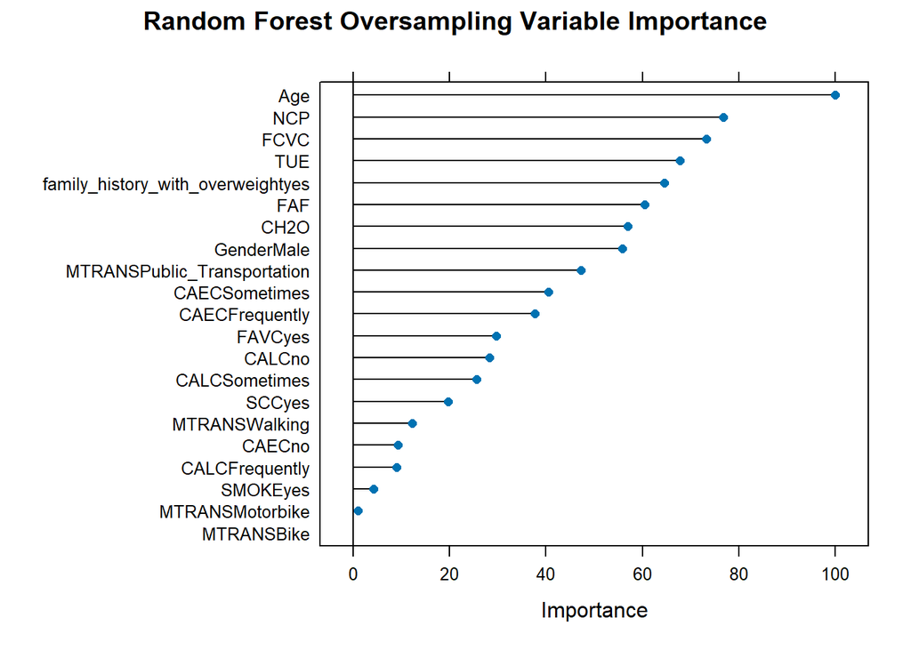

```r
plot(varImp(rf_over),
     main = "Random Forest Oversampling Variable Importance" )
```

Berdasarkan output di atas, tiga peubah terpenting adalah Age,NCP, dan FCVC.

### Modeling 2: Gradient Boosting

#### Cross Validation

```r
set.seed(123)
boost_over <- train(obesity ~.,
               data=over_data,
               method="gbm",
               tuneLength = 10,
               trControl=fitControl,
               verbose = FALSE)
boost_over
```

```
## Stochastic Gradient Boosting
##
## 3112 samples
##   14 predictor
##    4 classes: 'Insufficient', 'Normal', 'Obesity', 'Overweight'
##
## No pre-processing
## Resampling: Cross-Validated (5 fold)
## Summary of sample sizes: 2490, 2491, 2488, 2490, 2489
## Resampling results across tuning parameters:
##
##   interaction.depth  n.trees  Accuracy   Kappa
##    1                  50      0.6883211  0.5844213
##    1                 100      0.7265368  0.6353745
##    1                 150      0.7499997  0.6666609
```

[output cut: 104 more lines]

Hasil validasi silang ditampilkan pada plot berikut:

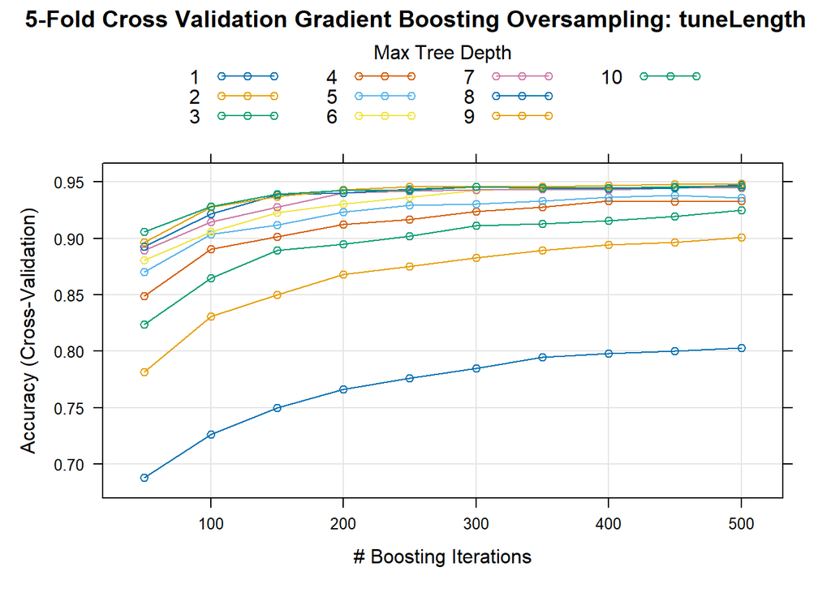

```r
plot(boost_over, main = "5-Fold Cross Validation Gradient Boosting Oversampling: tuneLength")
```

```r
boost_over_best <- boost_over$bestTune
boost_over_best
```

```
##    n.trees interaction.depth shrinkage n.minobsinnode
## 90     500                 9       0.1             10
```

Berdasarkan output di atas, tuning parameter terbaik adalah n.trees = 500, interaction.depth = 9, shrinkage = 0.1 dan n.minobsinnode = 10, yang memberikan Accuracy = 0.9482644 dan Kappa = 0.9310195

#### Re-Fit Model Menggunakan Tuning Parameter Terbaik

```r
set.seed(123)
boost_over <- train(obesity ~.,
               data=over_data,
               method="gbm",
               tuneGrid  = boost_over_best,
               verbose = FALSE)
boost_over
```

```
## Stochastic Gradient Boosting
##
## 3112 samples
##   14 predictor
##    4 classes: 'Insufficient', 'Normal', 'Obesity', 'Overweight'
##
## No pre-processing
## Resampling: Bootstrapped (25 reps)
## Summary of sample sizes: 3112, 3112, 3112, 3112, 3112, 3112, ...
## Resampling results:
##
##   Accuracy   Kappa
##   0.9306612  0.9075024
##
## Tuning parameter 'n.trees' was held constant at a value of 500
## Tuning
##
## Tuning parameter 'shrinkage' was held constant at a value of 0.1
##
## Tuning parameter 'n.minobsinnode' was held constant at a value of 10
```

```r
boost_over_result <- boost_over$results
boost_over_result
```

```
##   n.trees interaction.depth shrinkage n.minobsinnode  Accuracy     Kappa
## 1     500                 9       0.1             10 0.9306612 0.9075024
##    AccuracySD    KappaSD
## 1 0.009117478 0.01215236
```

Diperoleh Accuracy = 0.9306612 dan Kappa = 0.9075024

#### Evaluasi Terhadap Data Test

```r
boost_over_eval <- eval_test_data(boost_over)
boost_over_eval
```

```
##  Accuracy     Kappa
## 0.8551069 0.7868248
```

Diperoleh Accuracy sebesar 0.8551069

#### Variable Importance

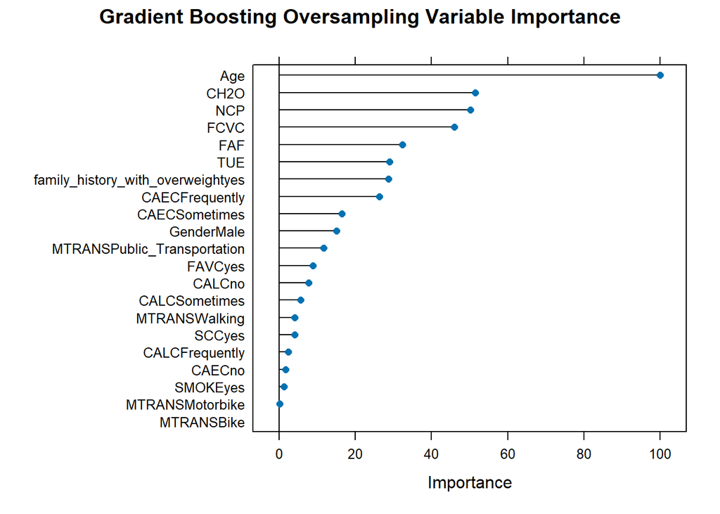

```r
plot(varImp(boost_over),
     main = "Gradient Boosting Oversampling Variable Importance" )
```

Berdasarkan output di atas, tiga peubah terpenting adalah Age,CH20, dan NCP.

## Undersampling

```r
set.seed(123)
under_data <- downSample(x = trainData[, 1:14], y = trainData$obesity, yname = "obesity")
table(under_data$obesity)
```

```
##
## Insufficient       Normal      Obesity   Overweight
##          218          218          218          218
```

### Modeling 1: Random Forest

#### Cross Validation

```r
set.seed(123)
rf_under <- train(obesity ~ .,
            data = under_data,
            method = 'ranger',
            tuneLength = 10,
            importance = "impurity",
            trControl = fitControl,
            verbose = FALSE)
rf_under
```

```
## Random Forest
##
## 872 samples
##  14 predictor
##   4 classes: 'Insufficient', 'Normal', 'Obesity', 'Overweight'
##
## No pre-processing
## Resampling: Cross-Validated (5 fold)
## Summary of sample sizes: 696, 699, 696, 699, 698
## Resampling results across tuning parameters:
##
##   mtry  splitrule   Accuracy   Kappa
##    2    gini        0.7671991  0.6896308
##    2    extratrees  0.7028735  0.6038671
##    4    gini        0.8151690  0.7535594
##    4    extratrees  0.7624632  0.6832968
##    6    gini        0.8220463  0.7627589
##    6    extratrees  0.7865698  0.7154369
##    8    gini        0.8185520  0.7580791
##    8    extratrees  0.7774658  0.7032867
##   10    gini        0.8174285  0.7565834
##   10    extratrees  0.7865239  0.7153680
##   12    gini        0.8185781  0.7581180
##   12    extratrees  0.7853679  0.7138218
##   14    gini        0.8093887  0.7458626
##   14    extratrees  0.7934209  0.7245621
##   16    gini        0.8082459  0.7443470
##   16    extratrees  0.7842248  0.7123065
##   18    gini        0.8025444  0.7367454
##   18    extratrees  0.7853481  0.7138098
##   21    gini        0.7967837  0.7290728
##   21    extratrees  0.7956934  0.7276048
##
## Tuning parameter 'min.node.size' was held constant at a value of 1
## Accuracy was used to select the optimal model using the largest value.
## The final values used for the model were mtry = 6, splitrule = gini
##  and min.node.size = 1.
```

Hasil Validasi silang didapatkan plot sebagai berikut

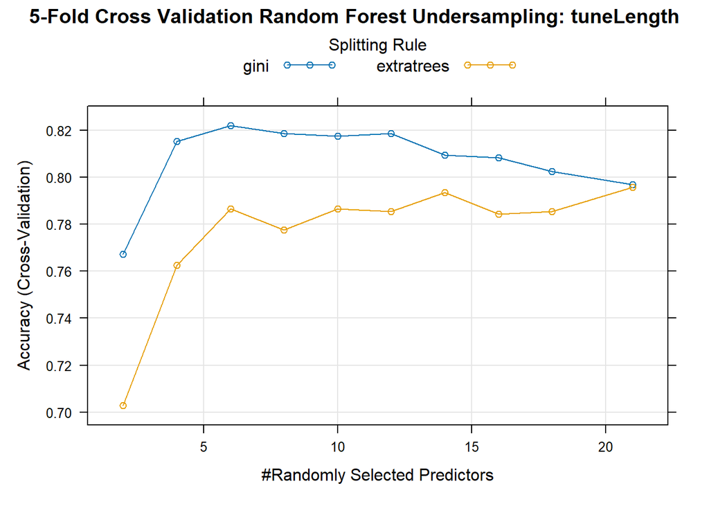

```r
plot(rf_under, main = "5-Fold Cross Validation Random Forest Undersampling: tuneLength")
```

```r
rf_under_best <- rf_under$bestTune
rf_under_best
```

```
##   mtry splitrule min.node.size
## 5    6      gini             1
```

Berdasarkan output di atas, tuning parameter terbaik adalah mtry = 6, splitrule = gini dan min.node.size = 1, yang memberikan nilai akurasi sebesar 0.8220463

#### Re-Fit Model Menggunakan Tuning Parameter Terbaik

```r
set.seed(123)
rf_under <- train(obesity ~ .,
            data = under_data,
            method = 'ranger',
            tuneGrid  = rf_under_best,
            importance = "impurity",
            verbose = FALSE)
rf_under
```

```
## Random Forest
##
## 872 samples
##  14 predictor
##   4 classes: 'Insufficient', 'Normal', 'Obesity', 'Overweight'
##
## No pre-processing
## Resampling: Bootstrapped (25 reps)
## Summary of sample sizes: 872, 872, 872, 872, 872, 872, ...
## Resampling results:
##
##   Accuracy   Kappa
##   0.8037875  0.7382724
##
## Tuning parameter 'mtry' was held constant at a value of 6
## Tuning
##  parameter 'splitrule' was held constant at a value of gini
## Tuning
##  parameter 'min.node.size' was held constant at a value of 1
```

```r
rf_under_result <- rf_under$results
rf_under_result
```

```
##   mtry splitrule min.node.size  Accuracy     Kappa AccuracySD    KappaSD
## 1    6      gini             1 0.8037875 0.7382724 0.02277013 0.03024481
```

Diperoleh model dengan Accuracy = 0.8037875 dan Kappa = 0.7382724

#### Model (mtry=6)

```r
set.seed(123)
rf_mod3<-randomForest(obesity~., data = under_data, mtry=6)
rf_mod3
```

```
##
## Call:
##  randomForest(formula = obesity ~ ., data = under_data, mtry = 6)
##                Type of random forest: classification
##                      Number of trees: 500
## No. of variables tried at each split: 6
##
##         OOB estimate of  error rate: 17.09%
## Confusion matrix:
##              Insufficient Normal Obesity Overweight class.error
## Insufficient          197     16       2          3  0.09633028
## Normal                 13    182       7         16  0.16513761
## Obesity                 0      7     186         25  0.14678899
## Overweight              3     28      29        158  0.27522936
```

#### Evaluasi Terhadap data Test

Untuk menguji kinerja model dalam memprediksi data baru, dilakukan evaluasi terhadap data testing

```r
rf_under_eval <- eval_test_data(rf_under)
rf_under_eval
```

```
##  Accuracy     Kappa
## 0.8123515 0.7278381
```

Diperoleh model dengan Accuracy = 0.8123515

#### Variable Importance

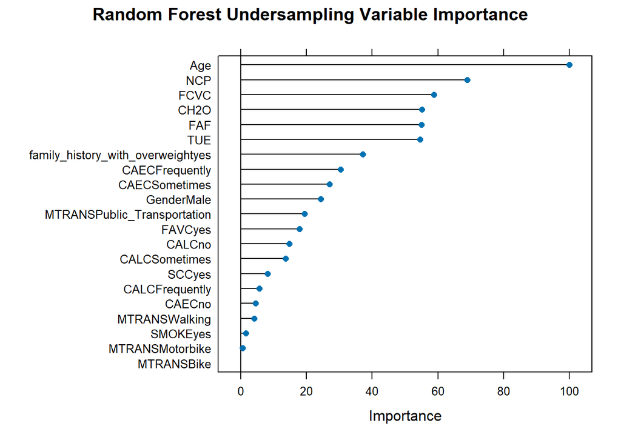

```r
plot(varImp(rf_under),
     main = "Random Forest Undersampling Variable Importance" )
```

Berdasarkan output di atas, tiga peubah terpenting adalah Age,NCP, dan FCVC.

### Modeling 2: Gradient Boosting

#### Cross Validation

```r
set.seed(123)
boost_under <- train(obesity ~.,
               data=under_data,
               method="gbm",
               tuneLength = 10,
               trControl=fitControl,
               verbose = FALSE)
boost_under
```

```
## Stochastic Gradient Boosting
##
## 872 samples
##  14 predictor
##   4 classes: 'Insufficient', 'Normal', 'Obesity', 'Overweight'
##
## No pre-processing
## Resampling: Cross-Validated (5 fold)
## Summary of sample sizes: 696, 699, 696, 699, 698
## Resampling results across tuning parameters:
##
##   interaction.depth  n.trees  Accuracy   Kappa
##    1                  50      0.6717661  0.5623867
##    1                 100      0.6878132  0.5837813
##    1                 150      0.7015609  0.6021236
```

[output cut: 104 more lines]

Hasil validasi silang ditampilkan pada plot berikut:

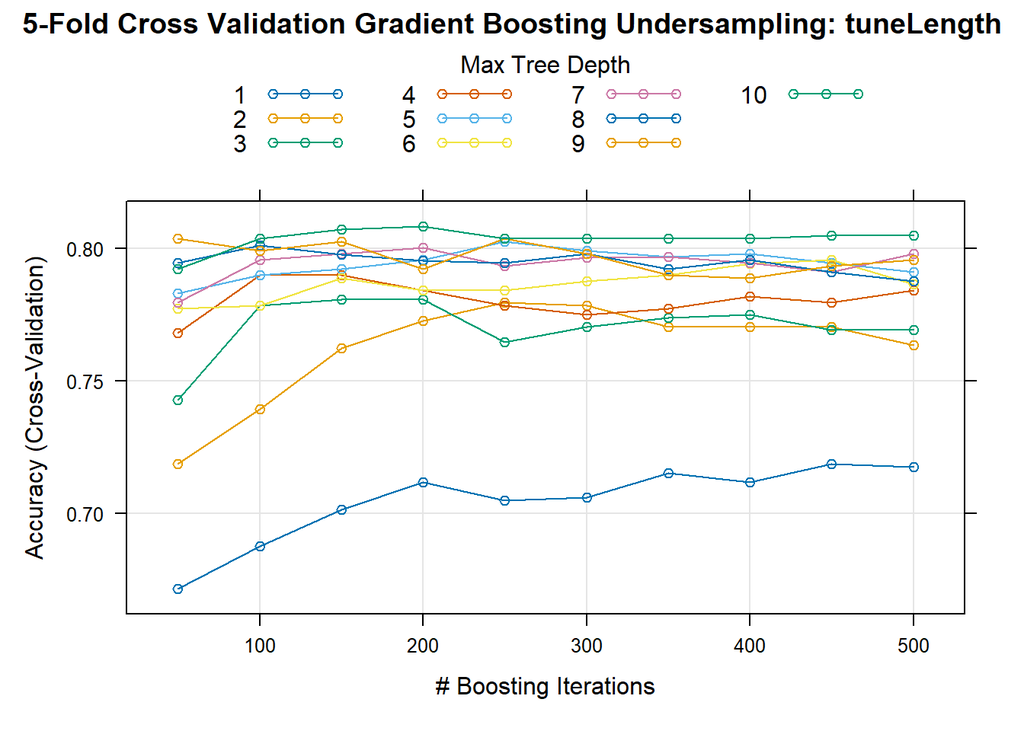

```r
plot(boost_under, main = "5-Fold Cross Validation Gradient Boosting Undersampling: tuneLength")
```

```r
boost_under_best <- boost_under$bestTune
boost_under_best
```

```
##    n.trees interaction.depth shrinkage n.minobsinnode
## 94     200                10       0.1             10
```

Berdasarkan output di atas, tuning parameter terbaik adalah n.trees = 200, interaction.depth = 10, shrinkage = 0.1 dan n.minobsinnode = 10, yang memberikan Accuracy = 0.8082661 dan Kappa = 0.7443765

#### Re-Fit Model Menggunakan Tuning Parameter Terbaik

```r
set.seed(123)
boost_under <- train(obesity ~.,
               data=under_data,
               method="gbm",
               tuneGrid  = boost_under_best,
               verbose = FALSE)
boost_under
```

```
## Stochastic Gradient Boosting
##
## 872 samples
##  14 predictor
##   4 classes: 'Insufficient', 'Normal', 'Obesity', 'Overweight'
##
## No pre-processing
## Resampling: Bootstrapped (25 reps)
## Summary of sample sizes: 872, 872, 872, 872, 872, 872, ...
## Resampling results:
##
##   Accuracy   Kappa
##   0.7842652  0.7122038
##
## Tuning parameter 'n.trees' was held constant at a value of 200
## Tuning
##
## Tuning parameter 'shrinkage' was held constant at a value of 0.1
##
## Tuning parameter 'n.minobsinnode' was held constant at a value of 10
```

```r
boost_under_result <- boost_under$results
boost_under_result
```

```
##   n.trees interaction.depth shrinkage n.minobsinnode  Accuracy     Kappa
## 1     200                10       0.1             10 0.7842652 0.7122038
##   AccuracySD    KappaSD
## 1 0.01847862 0.02446868
```

Diperoleh Accuracy = 0.7842652 dan Kappa = 0.7122038

#### Evaluasi Terhadap Data Test

```r
boost_under_eval <- eval_test_data(boost_under)
boost_under_eval
```

```
##  Accuracy     Kappa
## 0.7980998 0.7068509
```

Diperoleh Accuracy sebesar 0.7980998

#### Variable Importance

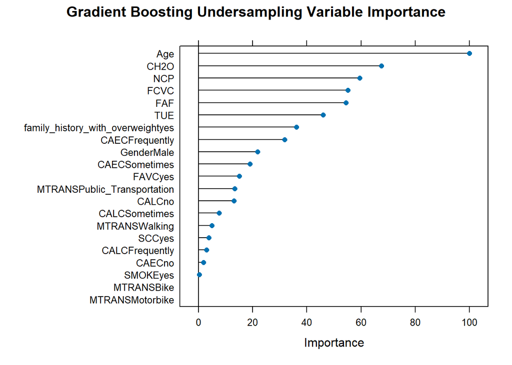

```r
plot(varImp(boost_under),
     main = "Gradient Boosting Undersampling Variable Importance" )
```

Berdasarkan output di atas, tiga peubah terpenting adalah Age,CH20, dan NCP.

## SMOTE

```r
# smote for multinomial classification
smote_data <- SmoteClassif(form = obesity ~ .,
                                dat = trainData,
                                C.perc = "balance",
                                dist = "HVDM")
table(smote_data$obesity)
```

```
##
## Insufficient       Normal      Obesity   Overweight
##          422          422          422          422
```

### Modeling 1: Random Forest

#### Cross Validation

```r
set.seed(123)
rf_smote <- train(obesity ~ .,
            data = smote_data,
            method = 'ranger',
            tuneLength = 10,
            importance = "impurity",
            trControl = fitControl,
            verbose = FALSE)
rf_smote
```

```
## Random Forest
##
## 1688 samples
##   14 predictor
##    4 classes: 'Insufficient', 'Normal', 'Obesity', 'Overweight'
##
## No pre-processing
## Resampling: Cross-Validated (5 fold)
## Summary of sample sizes: 1350, 1350, 1350, 1351, 1351
## Resampling results across tuning parameters:
##
##   mtry  splitrule   Accuracy   Kappa
##    2    gini        0.8157621  0.7543556
##    2    extratrees  0.7351922  0.6469497
##    4    gini        0.8637561  0.8183505
##    4    extratrees  0.8163644  0.7551560
##    6    gini        0.8756062  0.8341480
##    6    extratrees  0.8400558  0.7867477
##    8    gini        0.8720506  0.8294063
##    8    extratrees  0.8483522  0.7978108
##   10    gini        0.8720506  0.8294083
##   10    extratrees  0.8536811  0.8049122
##   12    gini        0.8649430  0.8199302
##   12    extratrees  0.8513125  0.8017537
##   14    gini        0.8619809  0.8159833
##   14    extratrees  0.8530771  0.8041060
##   16    gini        0.8596193  0.8128331
##   16    extratrees  0.8530859  0.8041186
##   18    gini        0.8572525  0.8096754
##   18    extratrees  0.8507243  0.8009659
##   21    gini        0.8519147  0.8025623
##   21    extratrees  0.8548628  0.8064870
##
## Tuning parameter 'min.node.size' was held constant at a value of 1
## Accuracy was used to select the optimal model using the largest value.
## The final values used for the model were mtry = 6, splitrule = gini
##  and min.node.size = 1.
```

Hasil Validasi silang didapatkan plot sebagai berikut

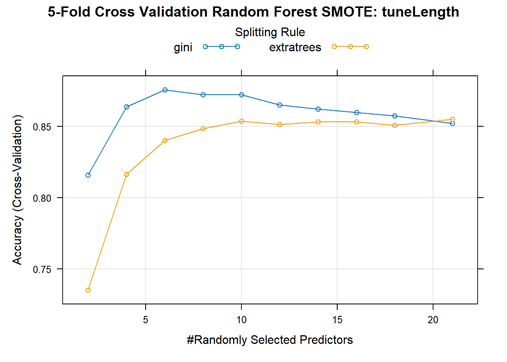

```r
plot(rf_smote, main = "5-Fold Cross Validation Random Forest SMOTE: tuneLength")
```

```r
rf_smote_best <- rf_smote$bestTune
rf_smote_best
```

```
##   mtry splitrule min.node.size
## 5    6      gini             1
```

Berdasarkan output di atas, tuning parameter terbaik adalah mtry = 6, splitrule = gini dan min.node.size = 1, yang memberikan nilai akurasi sebesar 0.8756062

#### Re-Fit Model Menggunakan Tuning Parameter Terbaik

```r
set.seed(123)
rf_smote <- train(obesity ~ .,
            data = smote_data,
            method = 'ranger',
            tuneGrid  = rf_smote_best,
            importance = "impurity",
            verbose = FALSE)
rf_smote
```

```
## Random Forest
##
## 1688 samples
##   14 predictor
##    4 classes: 'Insufficient', 'Normal', 'Obesity', 'Overweight'
##
## No pre-processing
## Resampling: Bootstrapped (25 reps)
## Summary of sample sizes: 1688, 1688, 1688, 1688, 1688, 1688, ...
## Resampling results:
##
##   Accuracy   Kappa
##   0.8620146  0.8159554
##
## Tuning parameter 'mtry' was held constant at a value of 6
## Tuning
##  parameter 'splitrule' was held constant at a value of gini
## Tuning
##  parameter 'min.node.size' was held constant at a value of 1
```

```r
rf_smote_result <- rf_smote$results
rf_smote_result
```

```
##   mtry splitrule min.node.size  Accuracy     Kappa AccuracySD    KappaSD
## 1    6      gini             1 0.8620146 0.8159554 0.01185336 0.01577293
```

Diperoleh model dengan Accuracy = 0.8620146 dan Kappa = 0.8159554

#### Model (mtry=6)

```r
set.seed(123)
rf_mod4<-randomForest(obesity~., data = smote_data, mtry=6)
rf_mod4
```

```
##
## Call:
##  randomForest(formula = obesity ~ ., data = smote_data, mtry = 6)
##                Type of random forest: classification
##                      Number of trees: 500
## No. of variables tried at each split: 6
##
##         OOB estimate of  error rate: 11.2%
## Confusion matrix:
##              Insufficient Normal Obesity Overweight class.error
## Insufficient          394     22       1          5  0.06635071
## Normal                  6    385       4         27  0.08767773
## Obesity                 0     16     380         26  0.09952607
## Overweight              4     55      23        340  0.19431280
```

#### Evaluasi Terhadap data Test

Untuk menguji kinerja model dalam memprediksi data baru, dilakukan evaluasi terhadap data testing

```r
rf_smote_eval <- eval_test_data(rf_smote)
rf_smote_eval
```

```
##  Accuracy     Kappa
## 0.8313539 0.7549215
```

Diperoleh model dengan Accuracy = 0.8313539

#### Variable Importance

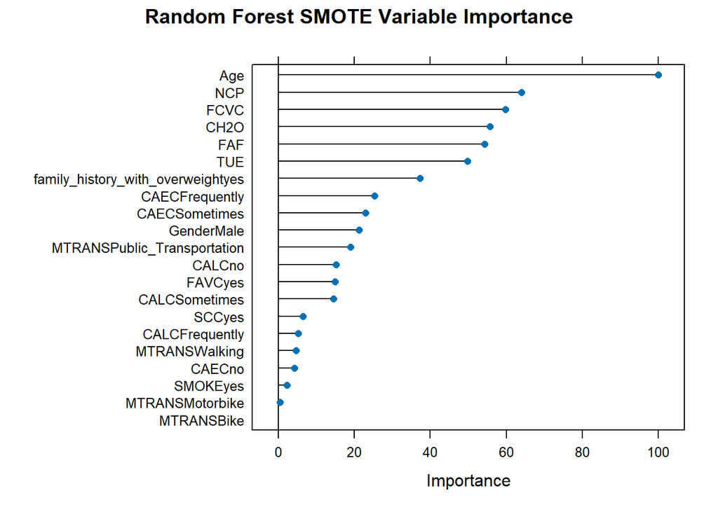

```r
plot(varImp(rf_smote),
     main = "Random Forest SMOTE Variable Importance" )
```

Berdasarkan output di atas, tiga peubah terpenting adalah Age,NCP, dan FCVC.

### Modeling 2: Gradient Boosting

#### Cross Validation

```r
set.seed(123)
boost_smote <- train(obesity ~.,
               data=smote_data,
               method="gbm",
               tuneLength = 10,
               trControl=fitControl,
               verbose = FALSE)
boost_smote
```

```
## Stochastic Gradient Boosting
##
## 1688 samples
##   14 predictor
##    4 classes: 'Insufficient', 'Normal', 'Obesity', 'Overweight'
##
## No pre-processing
## Resampling: Cross-Validated (5 fold)
## Summary of sample sizes: 1350, 1350, 1350, 1351, 1351
## Resampling results across tuning parameters:
##
##   interaction.depth  n.trees  Accuracy   Kappa
##    1                  50      0.6700402  0.5600433
##    1                 100      0.7020192  0.6026776
##    1                 150      0.7192071  0.6255947
```

[output cut: 104 more lines]

Hasil validasi silang ditampilkan pada plot berikut:

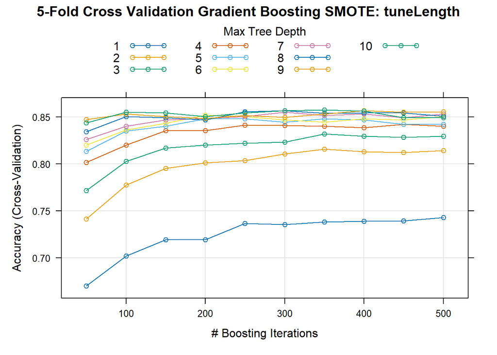

```r
plot(boost_smote, main = "5-Fold Cross Validation Gradient Boosting SMOTE: tuneLength")
```

```r
boost_smote_best <- boost_smote$bestTune
boost_smote_best
```

```
##    n.trees interaction.depth shrinkage n.minobsinnode
## 97     350                10       0.1             10
```

Berdasarkan output di atas, tuning parameter terbaik adalah n.trees = 350, interaction.depth = 10, shrinkage = 0.1 dan n.minobsinnode = 10, yang memberikan Accuracy = 0.8572402 dan Kappa = 0.8096568

#### Re-Fit Model Menggunakan Tuning Parameter Terbaik

```r
set.seed(123)
boost_smote <- train(obesity ~.,
               data=smote_data,
               method="gbm",
               tuneGrid  = boost_smote_best,
               verbose = FALSE)
boost_smote
```

```
## Stochastic Gradient Boosting
##
## 1688 samples
##   14 predictor
##    4 classes: 'Insufficient', 'Normal', 'Obesity', 'Overweight'
##
## No pre-processing
## Resampling: Bootstrapped (25 reps)
## Summary of sample sizes: 1688, 1688, 1688, 1688, 1688, 1688, ...
## Resampling results:
##
##   Accuracy   Kappa
##   0.8457748  0.7942514
##
## Tuning parameter 'n.trees' was held constant at a value of 350
## Tuning
##
## Tuning parameter 'shrinkage' was held constant at a value of 0.1
##
## Tuning parameter 'n.minobsinnode' was held constant at a value of 10
```

```r
boost_smote_result <- boost_smote$results
boost_smote_result
```

```
##   n.trees interaction.depth shrinkage n.minobsinnode  Accuracy     Kappa
## 1     350                10       0.1             10 0.8457748 0.7942514
##   AccuracySD    KappaSD
## 1 0.01427624 0.01904108
```

Diperoleh Accuracy = 0.8457748 dan Kappa = 0.7942514

#### Evaluasi Terhadap Data Test

```r
boost_smote_eval <- eval_test_data(boost_smote)
boost_smote_eval
```

```
##  Accuracy     Kappa
## 0.8171021 0.7330462
```

Diperoleh Accuracy sebesar 0.8171021

#### Variable Importance

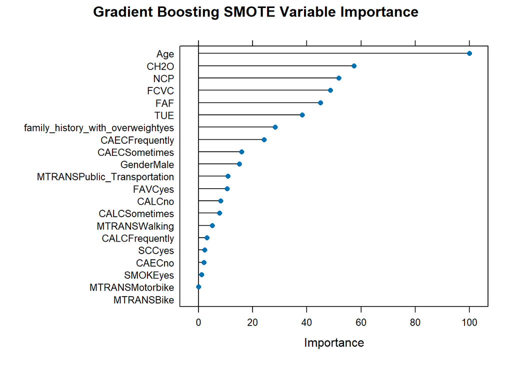

```r
plot(varImp(boost_smote),
     main = "Gradient Boosting SMOTE Variable Importance" )
```

Berdasarkan output di atas, tiga peubah terpenting adalah Age,CH20, dan NCP.

# Komparasi Model

Terdapat 8 model hasil dari Random Forest dan Gradient Boosting dari masing-masing data unbalanced yang belum ditangani, oversampling, undersampling dan SMOTE.

```r
eval_all <- matrix(c(rf_eval, rf_over_eval,rf_under_eval,rf_smote_eval, boost_eval, boost_over_eval,boost_under_eval,boost_smote_eval), nrow = 8, byrow = T)
colnames(eval_all) <- names(rf_eval)
row.names(eval_all) <- c("Random Forest Tanpa Penanganan",
                         "Random Forest Oversampling",
                         "Random Forest Undersampling",
                         "Random Forest SMOTE",
                         "Gradient Boosting Tanpa Penanganan",
                         "Gradient Boosting Oversampling",
                         "Gradient Boosting Undersampling",
                         "Gradient Boosting SMOTE")
eval_all
```

```
##                                     Accuracy     Kappa
## Random Forest Tanpa Penanganan     0.8337292 0.7534902
## Random Forest Oversampling         0.8432304 0.7690793
## Random Forest Undersampling        0.8123515 0.7278381
## Random Forest SMOTE                0.8313539 0.7549215
## Gradient Boosting Tanpa Penanganan 0.8408551 0.7645119
## Gradient Boosting Oversampling     0.8551069 0.7868248
## Gradient Boosting Undersampling    0.7980998 0.7068509
## Gradient Boosting SMOTE            0.8171021 0.7330462
```

Berdasarkan hasil diatas dapat dilihat nilai accuracy paling tinggi diperoleh melalui metode Gradient Boosting Oversampling dengan nilai akurasi sebesar 0.8551069. Berdasarkan plot variable importance sebelumnya diperoleh tiga peubah terpenting dalam meprediksi body mass index adalah Age,CH20, dan NCP.

# Confusion Matrix

```r
eval_test_data <- function(model) {
  pred <- predict(model, newdata = testData)

  # Create a confusion matrix using the table function
  confusion_matrix <- table(Actual = testData$obesity, Predicted = pred)

  # Display the confusion matrix
  print("Confusion Matrix:")
  print(confusion_matrix)

  # Calculate and display accuracy
  accuracy <- sum(diag(confusion_matrix)) / sum(confusion_matrix)
  cat("\nAccuracy:", accuracy, "\n")

  # Return accuracy and kappa
  return(c(Accuracy = accuracy, Kappa = kappa))
}

# Call the function with your boost_over model
evaluation_results <- eval_test_data(boost_over)
```

```
## [1] "Confusion Matrix:"
##               Predicted
## Actual         Insufficient Normal Obesity Overweight
##   Insufficient           44      8       1          1
##   Normal                  7     39       4          7
##   Obesity                 0      7     181          6
##   Overweight              1     12       7         96
##
## Accuracy: 0.8551069
```